# R Notebook

# Homework week 5 - day 2 - Thijmen

## Question 1

Load in the libraries you need, and look at the backpack data. Take note of variable names and dimensions.

```r
library(CodeClanData)
```

```r
dim(backpack)
head(backpack)
view(backpack)
```

[output not shown]

## Question 2

What is the distribution of backpack weights that students are carrying? Choose an appropriate graph to show the distribution.

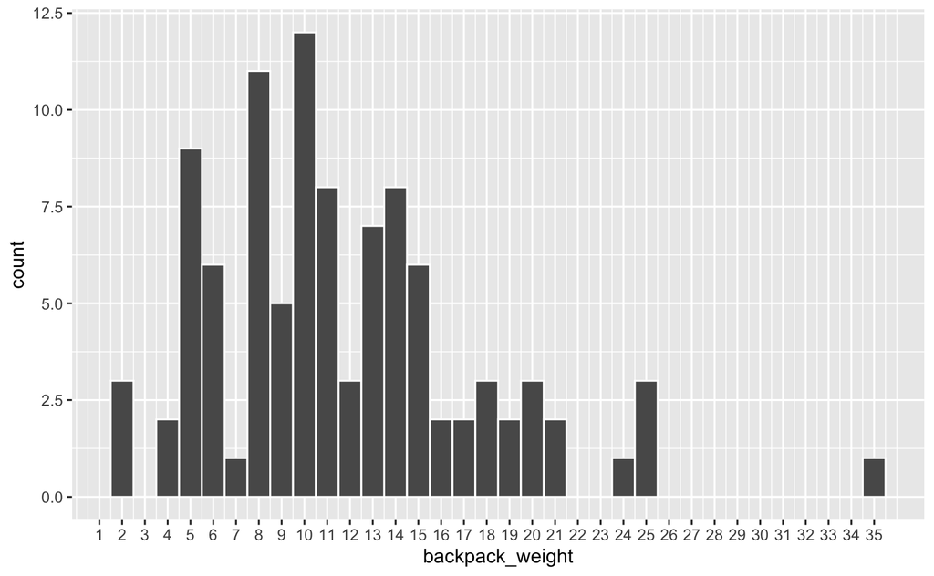

This graph shows the distribution of backpack weights among students. Most students have a backpack weight of 10 kg.

# Question 3

Are there differences in backpack weight between sex?

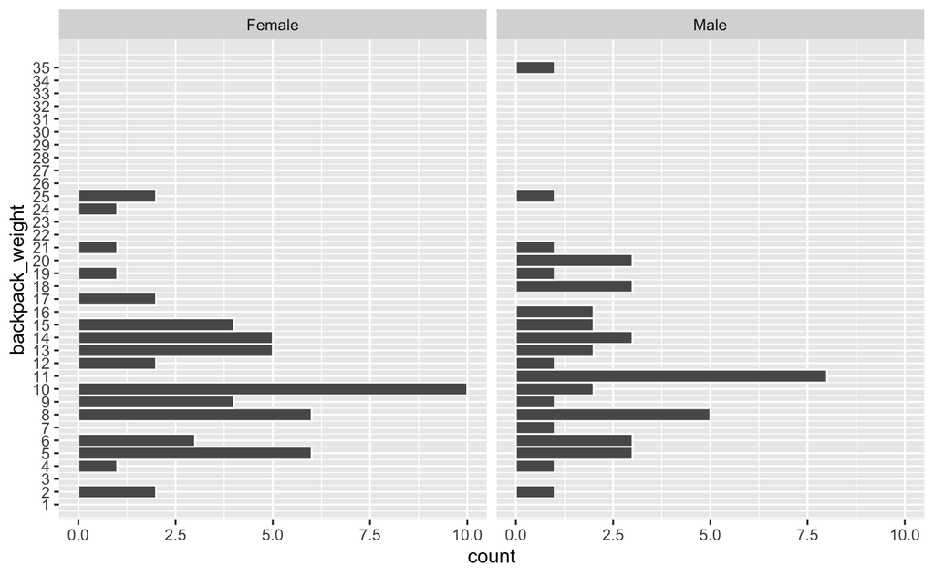

This histogram shows the distribution of backpack weights among students split per gender. We can see that in females, most common backpack weight (10 students) is 10 kg, while this is 11 kg in male students. Top bakcpack weight is 35 kg, caried around by a male student.

# Question 4

What is the relationship between body weight and backpack weight?

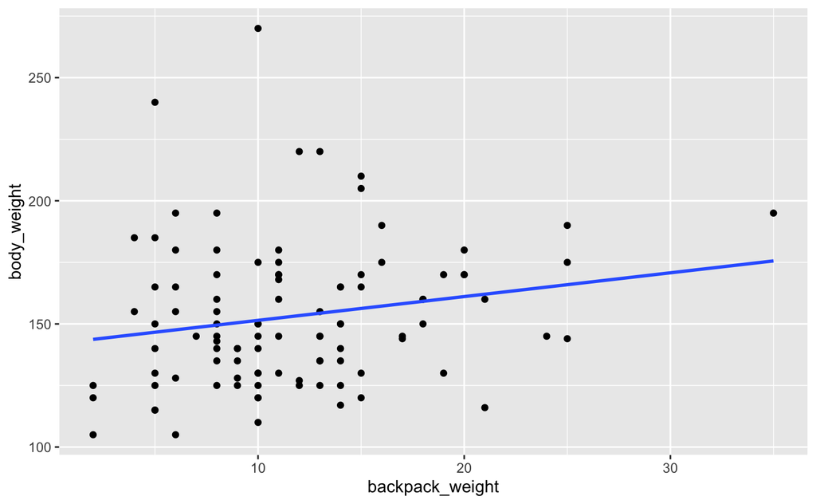

This scatterplot with linear regression line shows that there is a slight positive relationship between backpack_weight and body_weight. Heavier students tend to carry slightly heavier bakcpacks than their lighter students.

- Obviously we should need to statistically test if this is a significant positive relationship!

# Question 5

Is this relationship different between men and women? Choose an appropriate plot and interpret your findings.

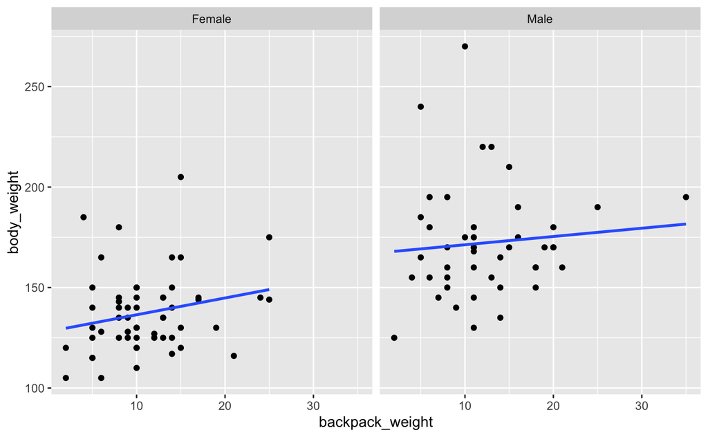

Breaking up the scatterplot by deviding them by sex shows that this positive relationship is slightly stronger among female students. While overall body weight of male students is higher.

- Obviously we should need to statistically test if this is a significant positive relationship!

# Question 6

What proportion of students report back pain?

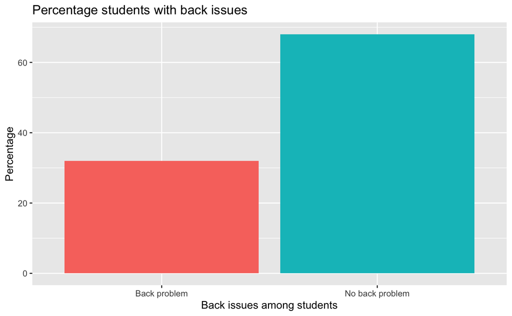

Based on the barplot, we can see that the proportion of students with backpain is 32%

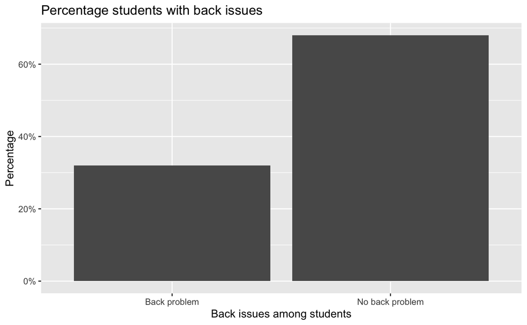

# Question 7

Is this proportion different between men and women?

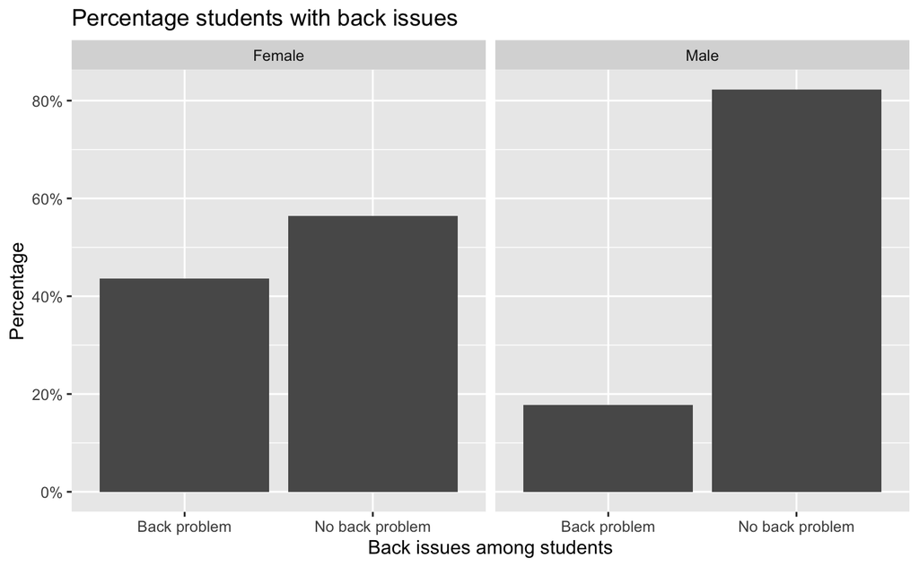

Yes this is different! Among females: ~42% have backpain, while this is ~19% among males!

# Question 8

Now you’ve investigated your data separately, create plots to describe the relationship between backpack weight, body weight, gender and reported backpain.

Try both backpack_weight and body_weight as well as the ratio.

Hint: faceting would be useful here.

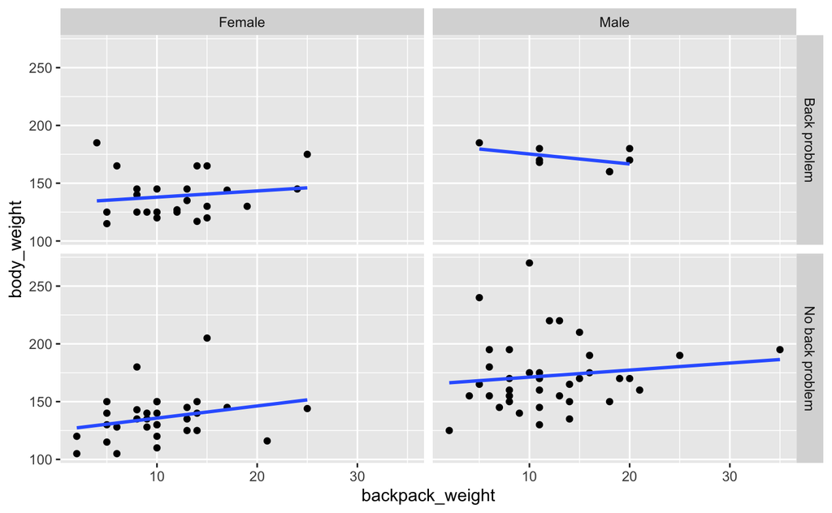

## Question 1

Does reported backpain differ across the year groups? Ignore year 0 in your data.

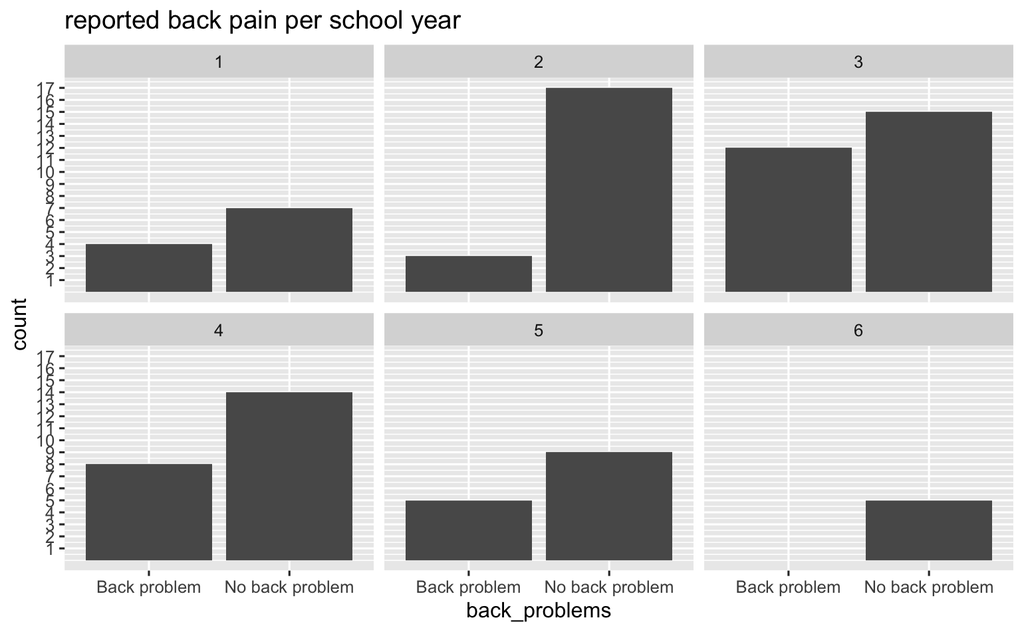

## Question 2

Is there a difference between how heavy the bags those in different years carry?

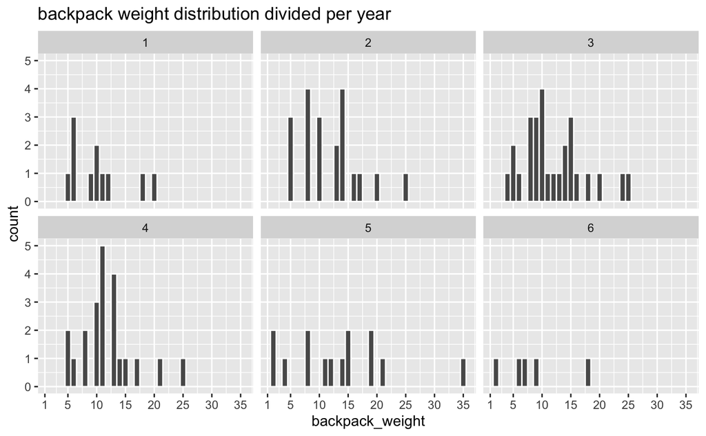